# 2016 US Presidential Campaign Finance in Nevada

## An Exploration by John Enyeart

# Introduction

For this project, I chose to work with one of the datasets suggested by Udacity. The dataset is Financial Contributions to Presidential Campaigns for a single state. I chose the state of Nevada because that is where I live. The data comes directly from the Federal Election Commission’s [website](http://fec.gov/disclosurep/pnational.do). There are 15,026 campaign contributions in the dataset to 21 presidential candidates. There are 18 variables that characterize each contribution, such as the contribution amount and the name, employer, city, and zip code of the contributor.

# Univariate Plots Section

### Summary and Initial Data Cleaning

```
## [1] 15207    18
```

```
##  [1] "cmte_id"           "cand_id"           "cand_nm"
##  [4] "contbr_nm"         "contbr_city"       "contbr_st"
##  [7] "contbr_zip"        "contbr_employer"   "contbr_occupation"
## [10] "contb_receipt_amt" "contb_receipt_dt"  "receipt_desc"
## [13] "memo_cd"           "memo_text"         "form_tp"
## [16] "file_num"          "tran_id"           "election_tp"
```

```
## 'data.frame':    15207 obs. of  18 variables:
##  $ cmte_id          : Factor w/ 21 levels "C00458844","C00500587",..: 7 7 7 7 7 7 7 7 7 7 ...
##  $ cand_id          : Factor w/ 21 levels "P00003392","P20002721",..: 10 10 10 10 10 10 10 10 10 10 ...
##  $ cand_nm          : Factor w/ 21 levels "Bush, Jeb","Carson, Benjamin S.",..: 17 17 17 17 17 17 17 17 17 17 ...
##  $ contbr_nm        : Factor w/ 4031 levels "& MARTILYN HEDGES-HILLER, SHARON",..: 290 341 365 3412 3412 286 1227 3250 3250 899 ...
##  $ contbr_city      : Factor w/ 86 levels "AUSTIN","BAKER",..: 24 59 34 45 45 34 60 59 59 59 ...
##  $ contbr_st        : Factor w/ 1 level "NV": 1 1 1 1 1 1 1 1 1 1 ...
##  $ contbr_zip       : int  890143609 895027724 891458810 893181055 893181055 891192048 890451531 895219308 895219308 895033626 ...
##  $ contbr_employer  : Factor w/ 1518 levels "","1ST ONE HUNDRED",..: 5 903 469 903 903 889 1086 727 727 903 ...
##  $ contbr_occupation: Factor w/ 1121 levels "","3D ARTIST",..: 447 659 575 659 659 1006 623 921 921 408 ...
##  $ contb_receipt_amt: num  15 200 100 27 5 50 50 100 25 28 ...
##  $ contb_receipt_dt : Factor w/ 366 levels "01-APR-15","01-AUG-15",..: 338 338 338 302 325 338 338 302 325 338 ...
##  $ receipt_desc     : Factor w/ 17 levels ""," SEE REATTRIBUTION",..: 1 1 1 1 1 1 1 1 1 1 ...
##  $ memo_cd          : Factor w/ 2 levels "","X": 1 1 1 1 1 1 1 1 1 1 ...
##  $ memo_text        : Factor w/ 38 levels ""," SEE REATTRIBUTION",..: 3 3 3 3 3 3 3 3 3 3 ...
##  $ form_tp          : Factor w/ 3 levels "SA17A","SA18",..: 1 1 1 1 1 1 1 1 1 1 ...
##  $ file_num         : int  1056899 1056899 1056899 1056899 1056899 1056899 1056899 1056899 1056899 1056899 ...
##  $ tran_id          : Factor w/ 15168 levels "A000E3D2280AB4E5AA70",..: 14485 14514 14371 14905 14945 14374 14475 15016 15111 14332 ...
##  $ election_tp      : Factor w/ 3 levels "","G2016","P2016": 3 3 3 3 3 3 3 3 3 3 ...
```

```
##  [1] "Bush, Jeb"                 "Carson, Benjamin S."
##  [3] "Christie, Christopher J."  "Clinton, Hillary Rodham"
##  [5] "Cruz, Rafael Edward 'Ted'" "Fiorina, Carly"
##  [7] "Graham, Lindsey O."        "Huckabee, Mike"
##  [9] "Jindal, Bobby"             "Kasich, John R."
## [11] "Lessig, Lawrence"          "O'Malley, Martin Joseph"
## [13] "Pataki, George E."         "Paul, Rand"
## [15] "Perry, James R. (Rick)"    "Rubio, Marco"
## [17] "Sanders, Bernard"          "Santorum, Richard J."
## [19] "Trump, Donald J."          "Walker, Scott"
## [21] "Webb, James Henry Jr."
```

```
##       cmte_id          cand_id                          cand_nm
##  C00577130:4284   P60007168:4284   Sanders, Bernard         :4284
##  C00575795:2994   P00003392:2994   Clinton, Hillary Rodham  :2994
##  C00574624:2770   P60006111:2770   Cruz, Rafael Edward 'Ted':2770
##  C00573519:2521   P60005915:2521   Carson, Benjamin S.      :2521
##  C00458844:1116   P60006723:1116   Rubio, Marco             :1116
##  C00575449: 540   P40003576: 540   Paul, Rand               : 540
##  (Other)  : 982   (Other)  : 982   (Other)                  : 982
##                   contbr_nm              contbr_city   contbr_st
##  SCHWEITZER, MARY      :  125   LAS VEGAS      :6315   NV:15207
##  AMICI, KEVIN          :   91   RENO           :2527
##  DOCTER, TIMOTHY E. MR.:   61   HENDERSON      :1934
##  WEST, DONNA           :   55   SPARKS         : 558
##  REYES, TRACI          :   52   CARSON CITY    : 540
##  BERINGER, TERESA      :   44   INCLINE VILLAGE: 523
##  (Other)               :14779   (Other)        :2810
##    contbr_zip             contbr_employer
##  Min.   :    53072   RETIRED      :3940
##  1st Qu.:891021920   NOT EMPLOYED : 929
##  Median :891351748   NONE         : 881
##  Mean   :858296718   N/A          : 829
##  3rd Qu.:894504223   SELF-EMPLOYED: 648
##  Max.   :898832377   (Other)      :7947
##                      NA's         :  33
##                               contbr_occupation contb_receipt_amt
##  RETIRED                               :4410    Min.   :-5400
##  NOT EMPLOYED                          :1392    1st Qu.:   25
##  INFORMATION REQUESTED PER BEST EFFORTS: 292    Median :   50
##  HOMEMAKER                             : 216    Mean   :  188
##  ATTORNEY                              : 212    3rd Qu.:  100
##  (Other)                               :8666    Max.   :10800
##  NA's                                  :  19
##   contb_receipt_dt                                  receipt_desc
##  29-FEB-16:  541                                          :14887
##  31-DEC-15:  276   Refund                                 :   78
##  20-FEB-16:  260   REDESIGNATION FROM PRIMARY             :   61
##  10-FEB-16:  254   REDESIGNATION TO GENERAL               :   61
##  02-FEB-16:  239   REATTRIBUTION / REDESIGNATION REQUESTED:   20
##  23-FEB-16:  233   REATTRIBUTION FROM SPOUSE              :   20
##  (Other)  :13404   (Other)                                :   80
##  memo_cd                                 memo_text      form_tp
##   :14674                                      :10612   SA17A:14805
##  X:  533   * EARMARKED CONTRIBUTION: SEE BELOW: 3987   SA18 :  324
##            * HILLARY VICTORY FUND             :  277   SB28A:   78
##            REDESIGNATION FROM PRIMARY         :   61
##            REDESIGNATION TO GENERAL           :   61
##            EARMARKED FROM MAKE DC LISTEN      :   54
##            (Other)                            :  155
##     file_num                       tran_id      election_tp
##  Min.   :1003942   AB37264C070244DDDBF7:    4        :    8
##  1st Qu.:1046958   ABB84C50DAFA6468C846:    4   G2016:  180
##  Median :1051507   ACAC3124F1343402CAF2:    4   P2016:15019
##  Mean   :1047579   A8329F352976046D0B76:    2
##  3rd Qu.:1056807   C1161747            :    2
##  Max.   :1056932   C2279509            :    2
##                    (Other)             :15189
```

A cursory look shows that there are 18 variables to work with covering financial contributions to 21 candidates. The median contribution amount is $50, the mean is $188 dollars, and the max is $10,800. According to this summary, the minimum contribution amount is -$5,400. There is no mention in the dataset description of why a negative number would be included, so I am going to remove any entries with a zero or negative contribution amount.

```r
pcf <- subset(pcf, contb_receipt_amt > 0)
summary(pcf$contb_receipt_amt)
```

```
##    Min. 1st Qu.  Median    Mean 3rd Qu.    Max.
##     1.0    25.0    50.0   203.5   100.0 10800.0
```

Now the minimum contribution is $1 and the mean is up to $203.50. The median and max contributions are unchanged.

```r
pcf <- pcf %>%
  separate(contb_receipt_dt, c("day",
                               "month",
                               "year"), sep = "-")
pcf$day <- as.integer(pcf$day)
pcf$year <- as.integer(pcf$year)
pcf$month <- match(pcf$month, toupper(month.abb))
```

Let’s also make a numeric variable that combines year and month into a single value so we can see finer differences in contribution dates on a numeric scale.

```r
pcf$year_with_months <- pcf$year + pcf$month / 12
```

Also, the city names in the dataset look like they need some cleaning:

```
##  [1] HENDERSON       RENO            LAS VEGAS       MC GILL
##  [5] ROUND MOUNTAIN  SPRING CREEK    NORTH LAS VEGAS SPARKS
##  [9] PAHRUMP         FERNLEY         BOULDER CITY    INCLINE VILLAGE
## [13] VERDI           CARSON CITY     STATELINE       WINNEMUCCA
## [17] GENOA           MANHATTAN       N LAS VEGAS     ZEPHYR COVE
## [21] LOS VEGAS       GARDNERVILLE    DAYTON          LOVELOCK
## [25] INCLINE VLG     GLENBROOK       MESQUITE        SILVER CITY
## [29] MINDEN          BAKER           RUBY VALLEY     SANDY VALLEY
## [33] FALLON          SILVER SPRINGS  ELKO            WASHOE VALLEY
## [37] TONOPAH         YERINGTON       CRYSTAL BAY     LAUGHLIN
## [41] VIRGINIA CITY   ELY             WINNEMUCA       CARLIN
## [45] SILVERPEAK      AUSTIN          VC HIGHLANDS    MOAPA
## [49] SMITH           MC DERMITT      PANACA          OVERTON
## [53] C               INDIAN SPRINGS  OROVADA         HERDERSON
## [57] WEST WENDOVER   CALIENTE        WELLINGTON      BATTLE MOUNTAIN
## [61] WADSWORTH       LUND            MCGILL          SUN VALLEY
## [65] INCLUNE VILLAGE LA VEGAS        STE 440-214     LOGANDALE
## [69] LAMOILLE        DEETH           HAWTHORNE       HEDERSON
## [73] STAGECOACH      COULDER CITY    UNIONVILLE      WELLS
## [77] PIOCHE          LAST VEGAS      LASVEGAS        LOS ANGELES
## [81] GOLDFIELD       BEATTY          HND.            INCLINE VILLA
## [85] NO. LAS VEGAS
## 86 Levels: AUSTIN BAKER BATTLE MOUNTAIN BEATTY BOULDER CITY C ... ZEPHYR COVE
```

As you can see, there’s a “Las Vegas”, a “Lasvegas”, a “Last Vegas”, and a “Los Vegas”–among other errors. Time to do some clean up. Instead of manually changing all of the bad names to the correct names, we can use the `zipcode` library to look up the zipcodes in the `contbr_zip` variable.

```
##  [1] 890143609 895027724 891458810 893181055 891192048 890451531 895219308
##  [8] 895033626 891081712 891171540 891293237 891348890 890122156 891184650
## [15] 898156200 890440330 891296027 891172512 890313721 894369037 891346650
## [22] 891022314 890484668 894088431 895064166 891051164 891567049 890142633
## [29] 890152782 895232024 890815230 891298916 891215713 890052362 890777185
## [36] 891213611 891441307 895011720 891011807 891294867 895032505 891191047
## [43] 895024939     89135
```

So, most of the zipcodes are in Zip+4 format. The zip codes in the `zipcode` library are only in 5-digit format, so let’s convert them to 5-digit format.

```r
pcf$contbr_zip <- substr(as.character(pcf$contbr_zip), 1, 5)
unique(pcf$contbr_zip)
```

```
##   [1] "89014" "89502" "89145" "89318" "89119" "89045" "89521" "89503"
##   [9] "89108" "89117" "89129" "89134" "89012" "89118" "89815" "89044"
##  [17] "89031" "89436" "89102" "89048" "89408" "89506" "89105" "89156"
##  [25] "89015" "89523" "89081" "89121" "89005" "89077" "89144" "89501"
##  [33] "89101" "89135" "89130" "89052" "89511" "89060" "89107" "89178"
##  [41] "89104" "89450" "89434" "89032" "89074" "89509" "89439" "89512"
##  [49] "89147" "89139" "89701" "89103" "89123" "89706" "89084" "89128"
##  [57] "89086" "89431" "89705" "89449" "89445" "89122" "89110" "89435"
##  [65] "89138" "89166" "89149" "89411" "89183" "89179" "89133" "89451"
##  [73] "89022" "89141" "89169" "89124" "89448" "89137" "89002" "89109"
##  [81] "89519" "89460" "89113" "89142" "89403" "89419" "89703" "89510"
##  [89] "89413" "89131" "89011" "89146" "89027" "89515" "89721" "89508"
##  [97] "89504" "89410" "89441" "89428" "89423" "89120" "89311" "89833"
## [105] "89009" "89019" "89143" "89016" "89406" "89429" "89801" "89061"
## [113] "89106" "89704" "89006" "89148" "89432" "89803" "89049" "89447"
## [121] "89407" "89402" "89028" "89440" "89161" "89193" "89029" "89034"
## [129] "89301" "89446" "89125" "89177" "89822" "89041" "89047" "89702"
## [137] "89140" "89310" "89111" "89315" "89115" "89126" "89116" "89112"
## [145] "89025" "89430" "89024" "89421" "89042" "89505" "89040" "89513"
## [153] "89085" "89533" "89018" "89425" "89008" "89162" "89507" "89030"
## [161] "89883" "89444" "89160" "89820" "89180" "89132" "89442" "89317"
## [169] "89433" "89158" "87451" "89021" "89828" "89823" "89415" "88510"
## [177] "89173" "89418" "89835" "89053" "89114" "89043" "59519" "89013"
## [185] "89003"
```

Looks good. Now let’s get rid of the `contbr_city` and `contbr_st` variables and join our data frame with the `zipcode` data frame so that we have `city`, `state`, `latitude`, and `longitude` variables in a clean format.

```r
data(zipcode)
names(pcf)[names(pcf) == 'contbr_zip'] <- 'zip'
pcf <- left_join(pcf, zipcode, by = 'zip')
# check our work
unique(pcf$city)
```

```
##  [1] "Henderson"            "Reno"                 "Las Vegas"
##  [4] "McGill"               "Round Mountain"       "Spring Creek"
##  [7] "North Las Vegas"      "Sparks"               "Pahrump"
## [10] "Fernley"              "Indian Springs"       "Boulder City"
## [13] "Incline Village"      "Verdi"                "Carson City"
## [16] "Stateline"            "Winnemucca"           "Genoa"
## [19] "Manhattan"            "Zephyr Cove"          "Gardnerville Ranchos"
## [22] "Dayton"               "Lovelock"             "Glenbrook"
## [25] "Mesquite"             "Gardnerville"         "Silver City"
## [28] "Minden"               "Baker"                "Ruby Valley"
## [31] "Jean"                 "Fallon"               "Silver Springs"
## [34] "Elko"                 "Washoe Valley"        "Tonopah"
## [37] "Yerington"            "Crystal Bay"          "Laughlin"
## [40] "Virginia City"        "Ely"                  "Carlin"
## [43] "Silverpeak"           "Austin"               "Moapa"
## [46] "Smith"                "McDermitt"            "Panaca"
## [49] "Overton"              "Orovada"              "Caliente"
## [52] "West Wendover"        "Wellington"           "Battle Mountain"
## [55] "Wadsworth"            "Lund"                 "Sun Valley"
## [58] NA                     "Logandale"            "Lamoille"
## [61] "Deeth"                "Hawthorne"            "El Paso"
## [64] "Imlay"                "Wells"                "Pioche"
## [67] "Goldfield"            "Beatty"
```

It looks like there are some NAs, so let’s see if we can fix that. Also, I see an “El Paso”, so let’s make sure that all of the cities are in Nevada.

```r
subset(pcf, is.na(city) | state != "NV")$contbr_city
```

```
##  [1] VERDI           VERDI           VERDI           MESQUITE
##  [5] VERDI           VERDI           MESQUITE        VERDI
##  [9] VERDI           VERDI           VERDI           VERDI
## [13] VERDI           VERDI           INCLINE VILLAGE VERDI
## [17] MESQUITE        RENO            VERDI           VERDI
## [21] VERDI           RENO            RENO            MESQUITE
## [25] MESQUITE        VERDI           VERDI           VERDI
## [29] VERDI           VERDI           MESQUITE
## 86 Levels: AUSTIN BAKER BATTLE MOUNTAIN BEATTY BOULDER CITY C ... ZEPHYR COVE
```

```r
subset(pcf, is.na(city) | state != "NV")$contbr_st
```

```
##  [1] NV NV NV NV NV NV NV NV NV NV NV NV NV NV NV NV NV NV NV NV NV NV NV
## [24] NV NV NV NV NV NV NV NV
## Levels: NV
```

```r
subset(pcf, is.na(city) | state != "NV")$zip
```

```
##  [1] "89439" "89439" "89439" "89024" "89439" "89439" "89024" "89439"
##  [9] "89439" "89439" "89439" "89439" "89439" "89439" "87451" "89439"
## [17] "89024" "88510" "89439" "89439" "89439" "59519" "59519" "89024"
## [25] "89024" "89439" "89439" "89439" "89439" "89439" "89024"
```

```r
subset(pcf, is.na(city) | state != "NV")$state
```

```
##  [1] "CA" "CA" "CA" "AZ" "CA" "CA" "AZ" "CA" "CA" "CA" "CA" "CA" "CA" "CA"
## [15] NA   "CA" "AZ" "TX" "CA" "CA" "CA" NA   NA   "AZ" "AZ" "CA" "CA" "CA"
## [29] "CA" "CA" "AZ"
```

```r
questionable.zips <- unique(subset(pcf, is.na(city) | state != "NV")$zip)
subset(zipcode, zip %in% questionable.zips)
```

```
##         zip     city state latitude longitude
## 39364 88510  El Paso    TX 31.69484 -106.3000
## 39467 89024 Mesquite    AZ 36.78943 -114.0104
## 39627 89439    Verdi    CA 39.52369 -120.0301
```

Okay, so a quick google search shows that the proper zip code for Incline Village is 89451, and that 89519 (not 59519) is a zip code in Reno.

Also, Verdi (89439) and Mesquite (89024) are in NV, not CA and AZ. El Paso (88510) is in TX, not NV, so let’s remove that entry from the data.

```r
pcf$zip[pcf$zip == "87451"] <- "89451"
pcf$zip[pcf$zip == "59519"] <- "89519"
pcf$state[pcf$zip %in% c("89439", "89024")] <- "NV"
# check our work
subset(pcf, is.na(city))$contbr_city
```

```
## [1] INCLINE VILLAGE RENO            RENO
## 86 Levels: AUSTIN BAKER BATTLE MOUNTAIN BEATTY BOULDER CITY C ... ZEPHYR COVE
```

```r
subset(pcf, is.na(city))$zip
```

```
## [1] "89451" "89519" "89519"
```

```r
# and fix the city, state, etc. variables for those entries
pcf$city[pcf$zip == "89451" & is.na(pcf$city)] <-
  zipcode$city[zipcode$zip == "89451"]
pcf$state[pcf$zip == "89451" & is.na(pcf$state)] <-
  zipcode$state[zipcode$zip == "89451"]
pcf$latitude[pcf$zip == "89451" & is.na(pcf$latitude)] <-
  zipcode$latitude[zipcode$zip == "89451"]
pcf$longitude[pcf$zip == "89451" & is.na(pcf$longitude)] <-
  zipcode$longitude[zipcode$zip == "89451"]
pcf$city[pcf$zip == "89519" & is.na(pcf$city)] <-
  zipcode$city[zipcode$zip == "89519"]
pcf$state[pcf$zip == "89519" & is.na(pcf$state)] <-
  zipcode$state[zipcode$zip == "89519"]
pcf$latitude[pcf$zip == "89519" & is.na(pcf$latitude)] <-
  zipcode$latitude[zipcode$zip == "89519"]
pcf$longitude[pcf$zip == "89519" & is.na(pcf$longitude)] <-
  zipcode$longitude[zipcode$zip == "89519"]
# clean up the variables that we no longer need
pcf <- subset(pcf, select = -contbr_city)
pcf <- subset(pcf, select = -contbr_st)
pcf <- subset(pcf, state != "TX")
```

Notably missing from the data set is the political party of the candidates. So, I will add that data based on the [website](http://fec.gov/disclosurep/pnational.do) that the data is from.

```r
reps <- list("Bush, Jeb", "Carson, Benjamin S.", "Christie, Christopher J.",
             "Cruz, Rafael Edward 'Ted'", "Fiorina, Carly",
             "Graham, Lindsey O.", "Huckabee, Mike", "Jindal, Bobby",
             "Kasich, John R.", "Pataki, George E.", "Paul, Rand",
             "Perry, James R. (Rick)", "Rubio, Marco", "Santorum, Richard J.",
             "Trump, Donald J.", "Walker, Scott")
dems <- list("Clinton, Hillary Rodham", "Lessig, Lawrence",
             "O'Malley, Martin Joseph", "Sanders, Bernard",
             "Webb, James Henry Jr.")

pcf$cand_pt <- ifelse(pcf$cand_nm %in% reps, 'R', 'D')
# ordered this way to make Republicans' plots red and Democrats' blue later on
pcf$cand_pt <- factor(pcf$cand_pt, levels = c("R", "D"))
```

I realized that there isn’t a lot of numeric data in this dataset besides the number of contributions and the dollar amount of those contributions, which would make bivariate and multivariate analysis a little bit difficult. So I decided to go to the [US Census Bureau website](http://factfinder.census.gov/faces/nav/jsf/pages/download_center.xhtml) to download the *2015 Population Estimates* and *Median Household Income in the Past 12 Months (in 2014 Inflation-Adjusted Dollars)* (from the [American Community Survey](https://www.census.gov/programs-surveys/acs/about.html)) datasets for all counties within Nevada.

A description of the 2015 Population Estimates dataset can be found in the accompanying file, *PEP_2015_PEPANNRES.txt*. The original CSV file is the file, *PEP_2015_PEPANNRES_with_ann.csv*. I made some modifications to the CSV file to make it load easier and to have variable names that made more sense to me. My modified version is the file, *nv_pop_by_county.csv*.

A description of the Median Household Income in the Past 12 Months (in 2014 Inflation-Adjusted Dollars) dataset from the American Community Survery can be found in the accompanying file, *ACS_14_5YR_B19013.txt*. The original CSV file is the file, *ACS_14_5YR_B19013_with_ann.csv*. I made some modifications to the CSV file to make it load easier and to have variable names that made more sense to me. My modified version is the file, *nv_household_income.csv*.

```r
np <- read.csv("nv_pop_by_county.csv")
ni <- read.csv("nv_household_income.csv")
```

These additional datasets have information for each county in Nevada, but the contribution data doesn’t have the county of the contribution sources listed - only city. So, I checked Wikipedia and found a [list of cities in Nevada](https://en.wikipedia.org/wiki/List_of_cities_in_Nevada) that also lists the county and population for each city. I wrote a Python script to scrape the table from the Wikipedia site to a CSV file. The Python script is the file, *dataScraping.py*, included with this report. The CSV file created by the script is the file, *nvCityCountyPop.csv*.

```r
ncc <- read.csv("nvCityCountyPop.csv")
ncc$city <- as.character(ncc$city)
ncc$county <- as.character(ncc$county)
```

Now let’s put it all together.

```r
pcf <- left_join(pcf, ncc, by = 'city')

# check to see if any entries have NA for the county variable
unique(subset(pcf, is.na(county))$city)
```

```
## [1] "Manhattan"   "Silver City" "Ruby Valley" "Silverpeak"  "Moapa"
## [6] "Smith"       "Overton"     "Logandale"   "Deeth"
```

It looks like there are a few cities that were left out of the Wikipedia page. I’ll just look those up individually and enter the proper counties by hand.

```r
pcf$county[pcf$city == "Manhattan"] <- "Nye"
pcf$city_pop[pcf$city == "Manhattan"] <- 124
pcf$county[pcf$city == "Silver City"] <- "Lyon"
pcf$city_pop[pcf$city == "Silver City"] <- 170
pcf$county[pcf$city == "Ruby Valley"] <- "Elko"
pcf$city_pop[pcf$city == "Ruby Valley"] <- 156
pcf$county[pcf$city == "Silverpeak"] <- "Esmeralda"
pcf$city_pop[pcf$city == "Silverpeak"] <- 107
pcf$county[pcf$city == "Moapa"] <- "Clark"
pcf$city_pop[pcf$city == "Moapa"] <- 1025
pcf$county[pcf$city == "Smith"] <- "Lyon"
pcf$city_pop[pcf$city == "Smith"] <- 1603
pcf$county[pcf$city == "Overton"] <- "Clark"
pcf$city_pop[pcf$city == "Overton"] <- 3901
pcf$county[pcf$city == "Logandale"] <- "Clark"
pcf$city_pop[pcf$city == "Logandale"] <- 3037
pcf$county[pcf$city == "Deeth"] <- "Elko"
pcf$city_pop[pcf$city == "Deeth"] <- 28
# check our work
length(row.names(subset(pcf, is.na(county) | is.na(city_pop))))
```

```
## [1] 0
```

Whew. Next, we will add in the census data for the counties.

```r
ni$county <- as.character(ni$county)
np$county <- as.character(np$county)

pcf <- pcf %>%
  left_join(select(ni, county, county_income), by = "county") %>%
  left_join(select(np, -id1, -id2), by = "county")

pcf$county <- as.factor(pcf$county)

# check for NAs
subset(pcf, is.na(county_income))
```

```
##  [1] cmte_id                          cand_id
##  [3] cand_nm                          contbr_nm
##  [5] zip                              contbr_employer
##  [7] contbr_occupation                contb_receipt_amt
##  [9] day                              month
## [11] year                             receipt_desc
## [13] memo_cd                          memo_text
## [15] form_tp                          file_num
## [17] tran_id                          election_tp
## [19] year_with_months                 city
## [21] state                            latitude
## [23] longitude                        cand_pt
## [25] county                           city_pop
## [27] county_income                    apr2010county_pop_census
## [29] apr2010county_pop_estimates_base jul2010county_pop_est
## [31] jul2011county_pop_est            jul2012county_pop_est
## [33] jul2013county_pop_est            jul2014county_pop_est
## [35] jul2015county_pop_est
## <0 rows> (or 0-length row.names)
```

Let’s create a new variable to look at contribution amount as a percentage of the median county income.

```r
pcf$amt_per_income <- pcf$contb_receipt_amt / pcf$county_income
```

Let’s look at some statistics for the added variables.

County Income:

```
##    Min. 1st Qu.  Median    Mean 3rd Qu.    Max.
##   31530   45090   51090   52480   59860   76560
```

July 2015 County Population Estimates:

```
##    Min. 1st Qu.  Median    Mean 3rd Qu.    Max.
##     829    5686   20610  180600   52100 2115000
```

And City Populations (from Wikipedia):

```
##     Min.  1st Qu.   Median     Mean  3rd Qu.     Max.
##      0.0    609.8   1742.0  25990.0   8264.0 603500.0
```

```
## Source: local data frame [1 x 9]
##
##    city     n total_amt mean_amt median_amt mean_amt_per_inc
##   (chr) (int)     (dbl)    (dbl)      (dbl)            (dbl)
## 1  Jean     2     87.24    43.62      43.62     0.0008377185
## Variables not shown: median_amt_per_inc (dbl), county_income (dbl),
##   city_pop (dbl)
```

Jean, NV is listed as having a population of zero. I thought this was an error, but according to [Wikipedia](https://en.wikipedia.org/wiki/Jean,_Nevada), that is correct!

### Number of Contributions

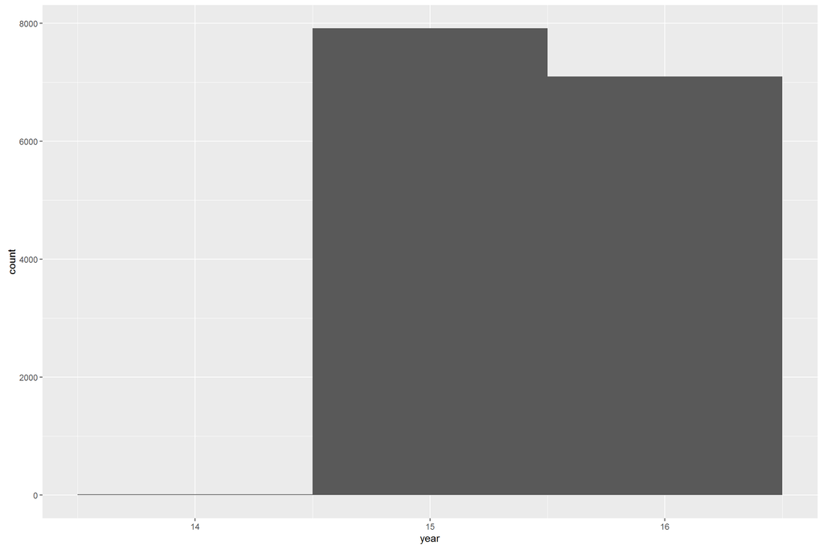

The contributions based on year alone doesn’t make a very interesting histogram. Let’s look at the histogram with the `year_with_months` variable that we just created.

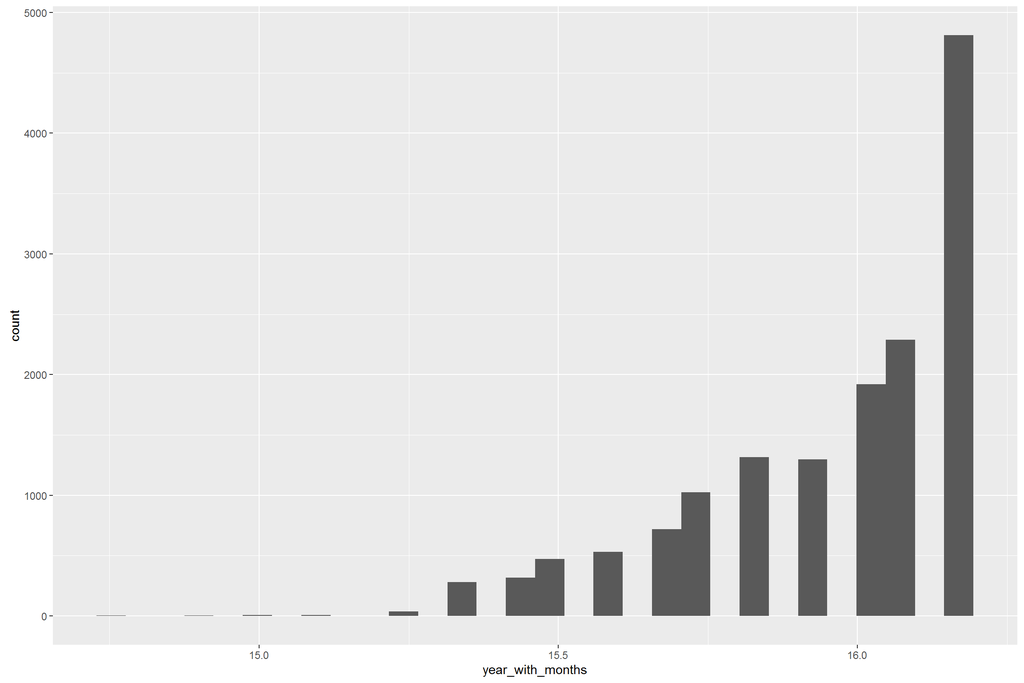

Let’s look at it another way: contribution months with a separate plot for each year.

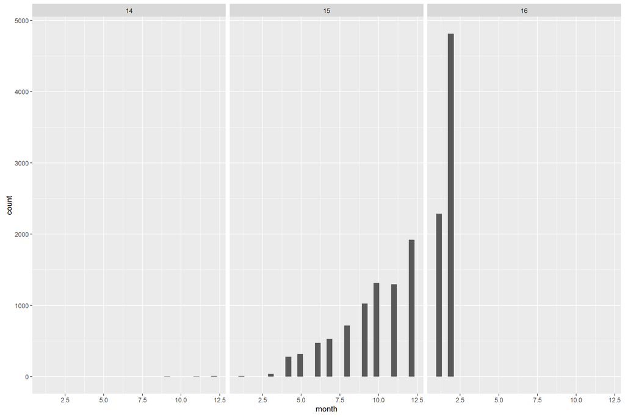

Alright, I guess that didn’t really show us anything we haven’t seen yet. Let’s move on and look at contributions per candidate and per political party.

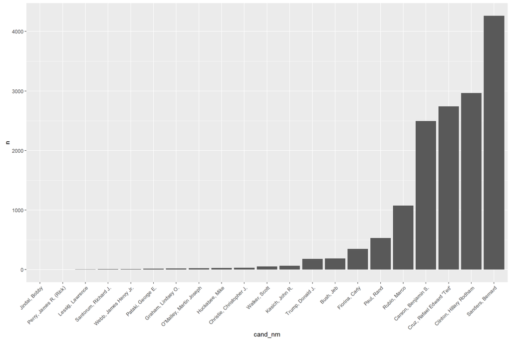

```
##                    cand_nm         n            total_amt
##  Jindal, Bobby         : 1   Min.   :   1.0   Min.   :   250
##  Perry, James R. (Rick): 1   1st Qu.:  13.0   1st Qu.:  9462
##  Lessig, Lawrence      : 1   Median :  53.0   Median : 27075
##  Santorum, Richard J.  : 1   Mean   : 715.5   Mean   :145611
##  Webb, James Henry Jr. : 1   3rd Qu.: 530.0   3rd Qu.:282465
##  Pataki, George E.     : 1   Max.   :4262.0   Max.   :832643
##  (Other)               :15
##     mean_amt         median_amt     mean_amt_per_inc   median_amt_per_inc
##  Min.   :  77.39   Min.   :  30.0   Min.   :0.001478   Min.   :0.0005987
##  1st Qu.: 250.00   1st Qu.: 100.0   1st Qu.:0.004989   1st Qu.:0.0018900
##  Median : 350.44   Median : 250.0   Median :0.006712   Median :0.0048012
##  Mean   : 565.84   Mean   : 412.1   Mean   :0.010807   Mean   :0.0078570
##  3rd Qu.: 752.50   3rd Qu.: 500.0   3rd Qu.:0.014517   3rd Qu.:0.0094500
##  Max.   :1678.57   Max.   :2700.0   Max.   :0.032002   Max.   :0.0510301
##
##    median_inc
##  Min.   :50108
##  1st Qu.:52070
##  Median :52401
##  Mean   :52274
##  3rd Qu.:52603
##  Max.   :53337
##
```

```
## Source: local data frame [2 x 8]
##
##                  cand_nm     n total_amt mean_amt median_amt
##                   (fctr) (int)     (dbl)    (dbl)      (dbl)
## 1          Jindal, Bobby     1       250      250        250
## 2 Perry, James R. (Rick)     1       250      250        250
## Variables not shown: mean_amt_per_inc (dbl), median_amt_per_inc (dbl),
##   median_inc (dbl)
```

```
## Source: local data frame [2 x 8]
##
##                  cand_nm     n total_amt mean_amt median_amt
##                   (fctr) (int)     (dbl)    (dbl)      (dbl)
## 1          Jindal, Bobby     1       250      250        250
## 2 Perry, James R. (Rick)     1       250      250        250
## Variables not shown: mean_amt_per_inc (dbl), median_amt_per_inc (dbl),
##   median_inc (dbl)
```

```
## Source: local data frame [1 x 8]
##
##                   cand_nm     n total_amt mean_amt median_amt
##                    (fctr) (int)     (dbl)    (dbl)      (dbl)
## 1 Clinton, Hillary Rodham  2965  832642.6 280.8238         50
## Variables not shown: mean_amt_per_inc (dbl), median_amt_per_inc (dbl),
##   median_inc (dbl)
```

We can see that the median number of contributions for a candidate is 53. There are two candidates tied for the minimum number of contributions: 1, and Bernie Sanders has the most contributions with 4,262.

As far as dollar amount, the two candidates with the lowest total amount had only $250 (and were also the same two candidates with only one contribution), the median was $27,075, and the max amount was $832,643, which went to Hillary Clinton.

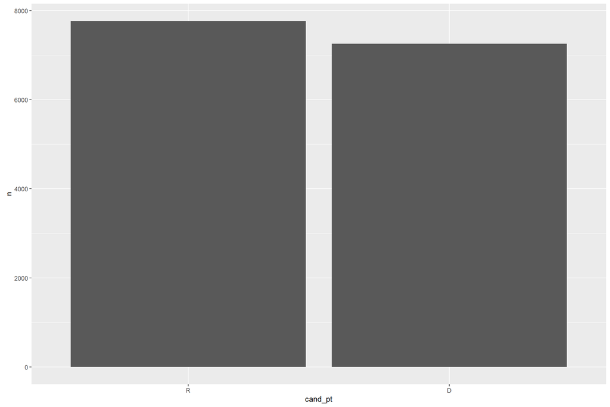

```
## Source: local data frame [2 x 8]
##
##   cand_pt     n total_amt mean_amt median_amt mean_amt_per_inc
##    (fctr) (int)     (dbl)    (dbl)      (dbl)            (dbl)
## 1       D  7259   1184627 163.1943         35      0.003121604
## 2       R  7766   1873199 241.2051         50      0.004564570
## Variables not shown: median_amt_per_inc (dbl), median_inc (dbl)
```

It’s interesting to see that Hillary Clinton and Bernie Sanders have more contributions than any other candidate, but that there are still more total contributions to the Republican Party than there are to the Democratic Party.

Some statistics:

The Democratic Party had 7,259 contributions for a total dollar amount of $1,184,627 with a median contribution amount of $35.

The Republican Party had 7,766 contributions for a total dollar amount of $1,873,199 with a median contribution amount of $50.

# Univariate Analysis

### What is the structure of your dataset?

There are 15,026 campaign contributions in the dataset to 21 presidential candidates. There are 18 variables that characterize each contribution:

- committee ID
- candidate ID
- candidate name
- contributor name
- contributor city
- contributor state
- contributor zip
- contributor employer
- contributor occupation
- contribution receipt amount
- contribution receipt date
- receipt description
- memo code
- memo text
- form type
- file number
- transaction ID
- election type/primary general indicator

Detailed descriptions of each of these variables can be found in the accompanying *dataDescription.txt* file.

The 21 candidates are:

- Republicans
  - Jeb Bush
  - Ben Carson
  - Chris Christie
  - Ted Cruz
  - Carly Fiorina
  - Lindsey Graham
  - Mike Huckabee
  - Bobby Jindal
  - John Kasich
  - George Pataki
  - Rand Paul
  - Rick Perry
  - Marco Rubio
  - Rick Santorum
  - Donald Trump
  - Scott Walker
- Democrats
  - Hillary Clinton
  - Lawrence Lessig
  - Martin O’Malley
  - Bernie Sanders
  - James Webb

The data required a bit of cleanup as the minimum contribution amount was -$5,400. There is no mention in the dataset description of why a negative number would be included, so I removed any entries with a zero or negative contribution amount.

Additional data was added to give more variables to work with. Four additional datasets were joined to the campaign finance dataset.

- Zipcode data from the R zipcode library.
- The [US Census Bureau’s](http://factfinder.census.gov/faces/nav/jsf/pages/download_center.xhtml) *2015 Population Estimates*, described in *PEP_2015_PEPANNRES.txt*.
- The [US Census Bureau’s](http://factfinder.census.gov/faces/nav/jsf/pages/download_center.xhtml) *Median Household Income in the Past 12 Months (in 2014 Inflation-Adjusted Dollars)*, described in *ACS_14_5YR_B19013.txt*.
- City and county data scraped from [Wikipedia](https://en.wikipedia.org/wiki/List_of_cities_in_Nevada) using the *dataScraping.py* script.

These additional datasets added (corrected) city names, county names, median county incomes, and county population estimates to the data. The lowest median county income is $31,530, the highest is $76,560, the median is $51,090, and the mean is $52,480. The smallest city population is 0, the largest is 603,500, the mean is 25,990, and the median is 1,742. The smallest 2015 county population estimate is 829, the largest is 2,115,000, the median is 20,610, and the mean is 180,600.

##### Other Observations

The mean contribution amount is $203.50, the median is $50, and the max is $10,800.

Contributions came from donors of 1121 different occupations and 86 cities throughout Nevada.

### What is/are the main feature(s) of interest in your dataset?

The main features of interest are the number of contributions, the amount of those contributions, who those contributions are going to, and where those contributions are from. I also added in population and median income data gathered from the US Census Bureau and scraped from Wikipedia.

### What other features in the dataset do you think will help support your investigation into your feature(s) of interest?

It may be interesting to look at which occupations donated to to which political party, how many people made multiple contributions, and the timeline of those contributions.

### Did you create any new variables from existing variables in the dataset?

Yes. I split the contribution receipt date variable into three variables: `year`, `month`, and `day`. I made a further variable called `year_with_months` that is a combination of year and month, with the month representing the a certain fraction of the year. Political parties for the candidates were also missing from the dataset, so I added in a variable, `cand_pt`, to record that based on the candidate name.

With the additional data, I created one new variable called `amt_per_income`, which gives the contribution amount as a percentage of the median income of the county from which that contribution came.

### Of the features you investigated, were there any unusual distributions? Did you perform any operations on the data to tidy, adjust, or change the form of the data? If so, why did you do this?

Although histograms such as number and amount of contributions came out decidedly skewed, I did not feel it was appropriate to try to transform the data (by converting to a logarithmic scale, for example) because the skewed (untransformed) version of the data speaks for itself.

# Bivariate Plots Section

Let’s start off with a look at contribution amounts.

### Total Contribution Amounts

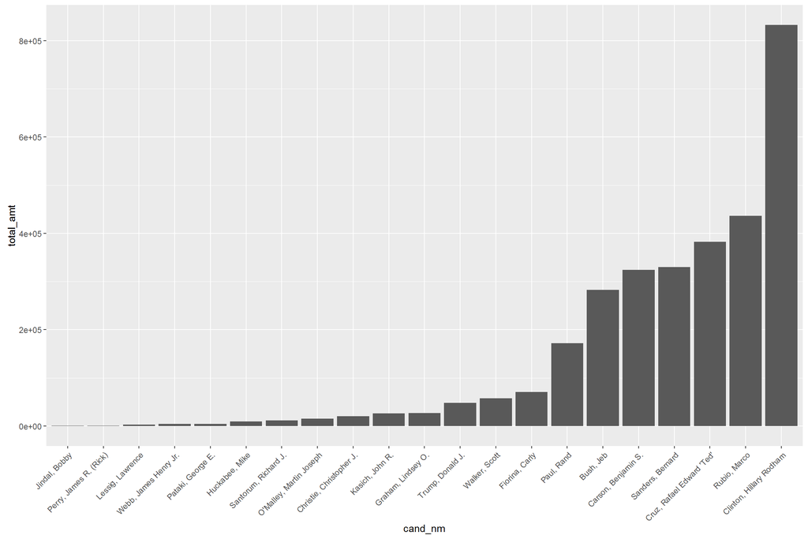

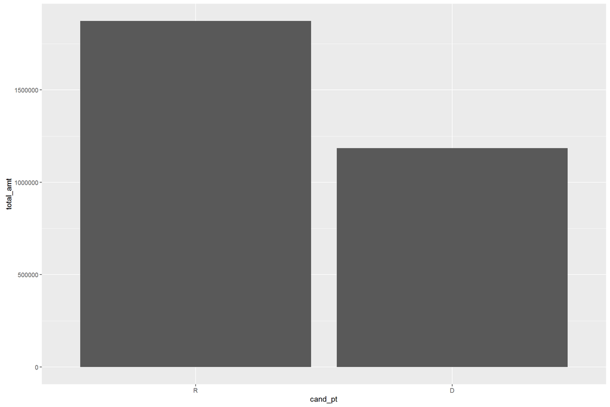

Even though Bernie Sanders is clearly the leader in total number of contributions, he only ranks fourth by total amount of contributions!

Let’s use box plots to look at the distribution of contribution amounts for each candidate.

### Contribution Amount Box Plots

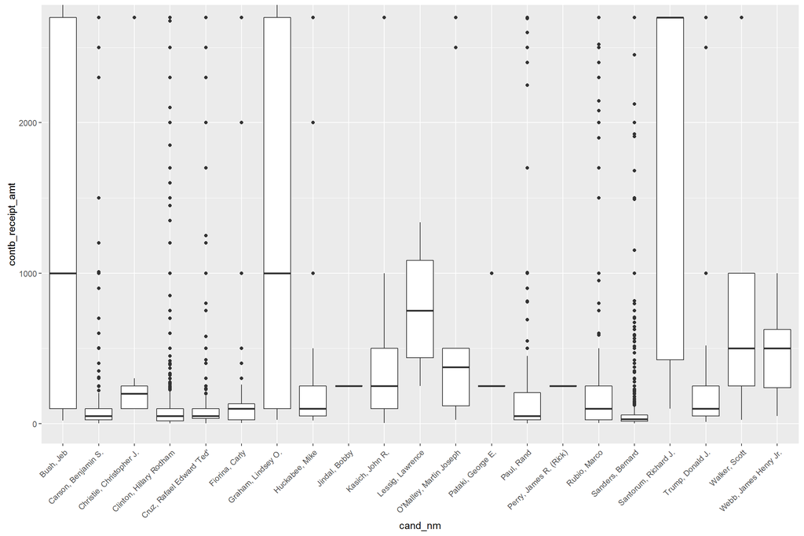

It looks like Jeb Bush, Rick Santorum, and Lindsey Graham all have very large contribution amounts compared to everybody else. However, this may be an artifact due to their relatively low number of contributions. Let’s take a look at the numbers.

```
## Source: local data frame [21 x 8]
##
##                      cand_nm     n total_amt   mean_amt median_amt
##                       (fctr) (int)     (dbl)      (dbl)      (dbl)
## 1              Jindal, Bobby     1    250.00  250.00000        250
## 2     Perry, James R. (Rick)     1    250.00  250.00000        250
## 3           Lessig, Lawrence     4   3087.00  771.75000        750
## 4       Santorum, Richard J.     7  11750.00 1678.57143       2700
## 5      Webb, James Henry Jr.     8   4000.00  500.00000        500
## 6          Pataki, George E.    13   4000.00  307.69231        250
## 7         Graham, Lindsey O.    18  27075.00 1504.16667       1000
## 8    O'Malley, Martin Joseph    20  15050.00  752.50000        375
## 9             Huckabee, Mike    27   9462.00  350.44444        100
## 10  Christie, Christopher J.    30  20550.00  685.00000        200
## 11             Walker, Scott    53  57450.00 1083.96226        500
## 12           Kasich, John R.    64  25956.00  405.56250        250
## 13          Trump, Donald J.   177  47865.95  270.42910        100
## 14                 Bush, Jeb   187 282465.00 1510.50802       1000
## 15            Fiorina, Carly   348  70751.57  203.30911        100
## 16                Paul, Rand   530 171705.51  323.97266         50
## 17              Rubio, Marco  1073 436627.81  406.92247        100
## 18       Carson, Benjamin S.  2496 324390.64  129.96420         50
## 19 Cruz, Rafael Edward 'Ted'  2741 382649.15  139.60202         50
## 20   Clinton, Hillary Rodham  2965 832642.63  280.82382         50
## 21          Sanders, Bernard  4262 329847.82   77.39273         30
## Variables not shown: mean_amt_per_inc (dbl), median_amt_per_inc (dbl),
##   median_inc (dbl)
```

Rick Santorum only has 7 contributions, Lindsey Graham has 18, and Jeb Bush has 187. So, the box plot *might* be a decent representation for Jeb Bush, but the lack of data skews the plot for the other two.

Let’s break this out by party.

Republicans:

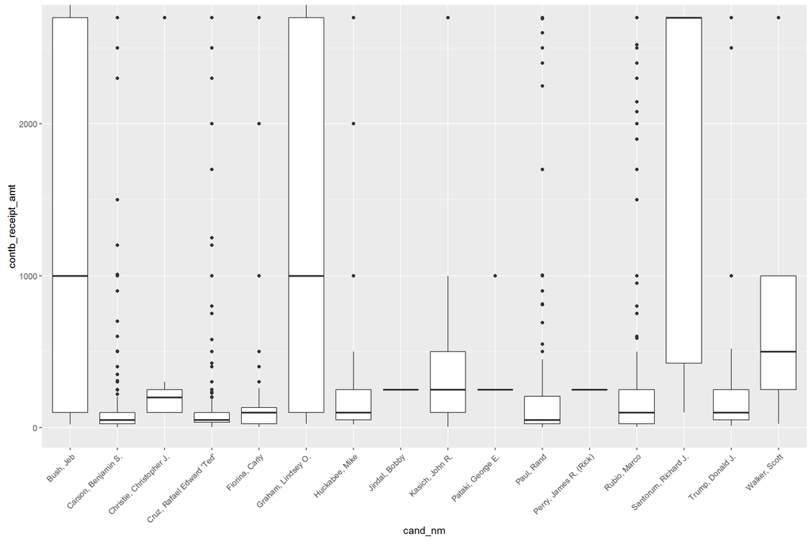

Democrats:

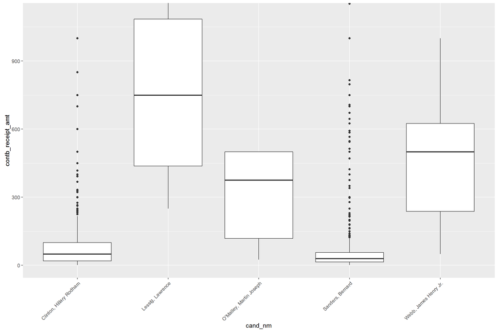

Interesting. The five candidates with the highest *total* contribution amounts, Hillary Clinton, Marco Rubio, Ted Cruz, Bernie Sanders, and Ben Carson all have relatively low individual contribution amounts. Let’s take a closer look at just these five candidates. Note that the top five by total contribution amount is the same group as the top five by number of contributions, but in different order.

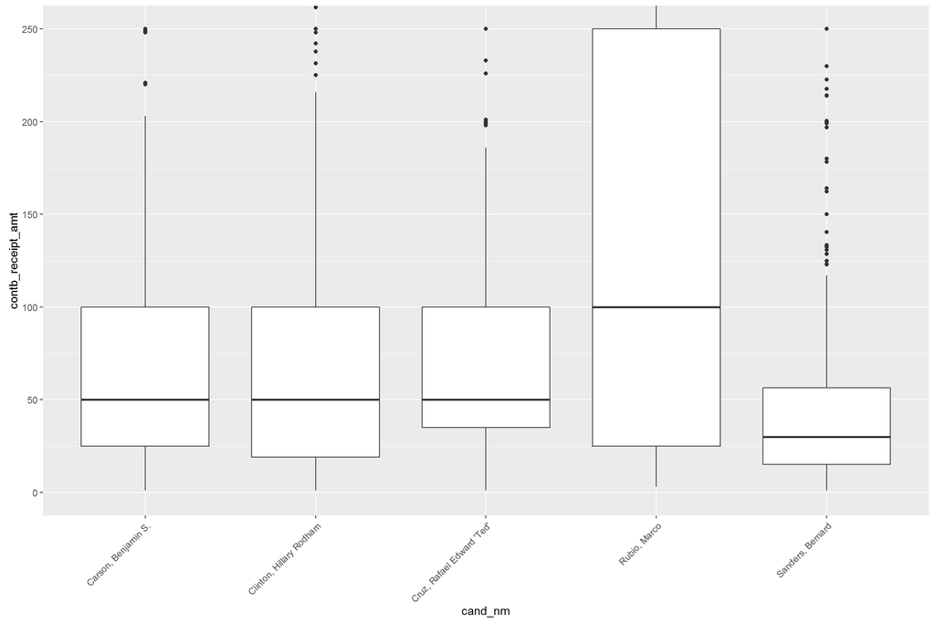

So, even though Bernie Sanders is the clear leader in total number of contributions, the average amount of each of those contributions is lower than anyone else. Conversely, Marco Rubio has much fewer contributions than anyone else in the top five, but he is the clear leader when it comes to average contribution amount among these five. It is also interesting to note that most of the quartiles come out to nice even numbers like $25, $50, or $100.

Finally, let’s look at the box plots by party.

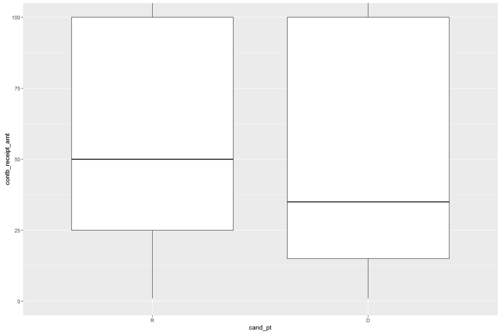

### Median Income of Contributors

Let’s look at the income of contributors. Note that in the groupings below, the original `county_income` variable is the *median* income for that county, so I used the *mean* of those medians to produce the `median_inc` variable.

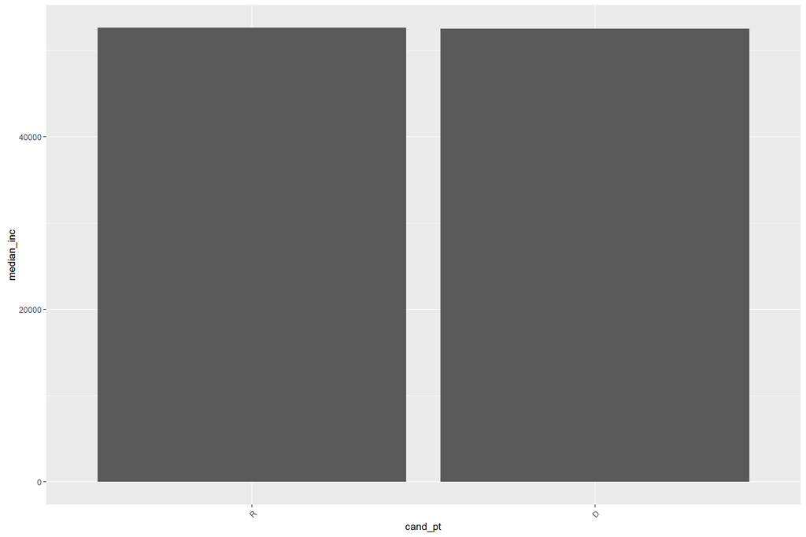

```
## Source: local data frame [2 x 2]
##
##   cand_pt median_inc
##    (fctr)      (dbl)
## 1       D   52504.94
## 2       R   52633.70
```

Here we see that the median income of Republican Party contributors is $52,633.70 and the median income for Democratic Party contributors is $52,504.94.

And let’s look by candidate rather than party.

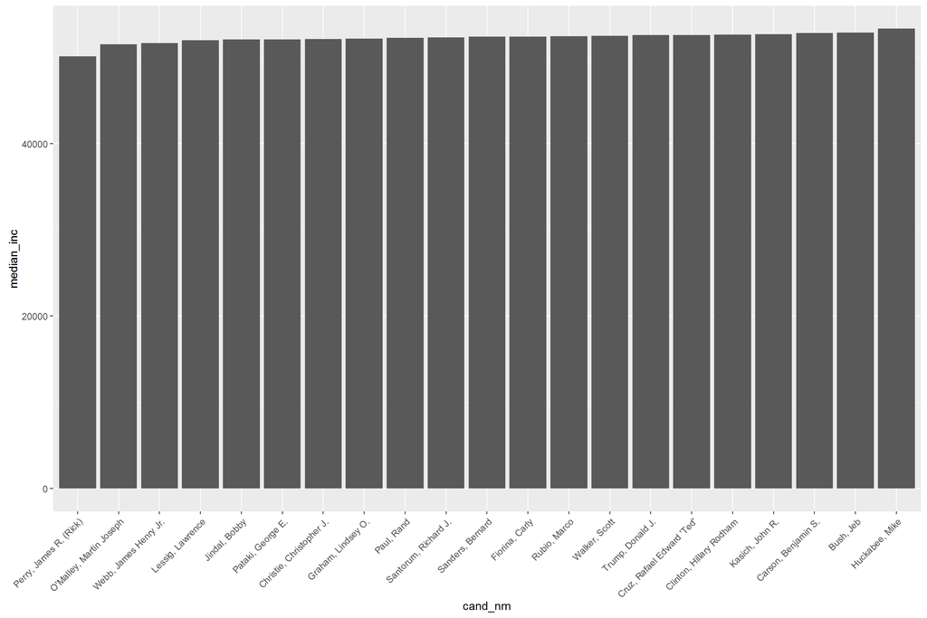

Not too interesting and not surprising since the median incomes are by county and only vary between $31,530 and $76,560. So let’s look at contributions as a percentage of median income.

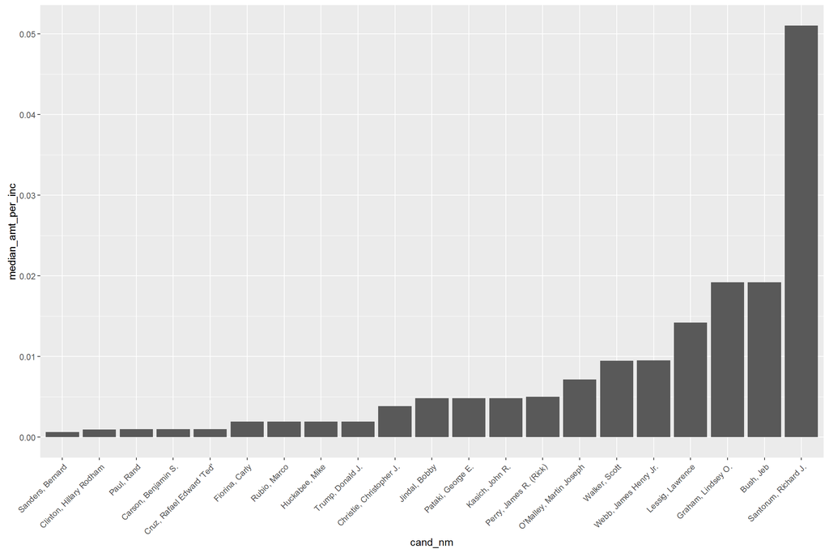

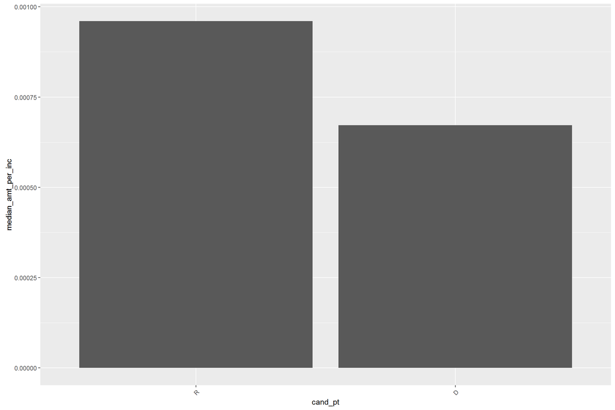

```
## Source: local data frame [2 x 2]
##
##   cand_pt median_amt_per_inc
##    (fctr)              (dbl)
## 1       D       0.0006721721
## 2       R       0.0009602458
```

This is a bit more interesting. It looks like Republican supporters may be more willing to spend a larger portion (about 0.1%) of their income on campaign contributions than Democrats (about 0.07%). Let’s look at the box plots.

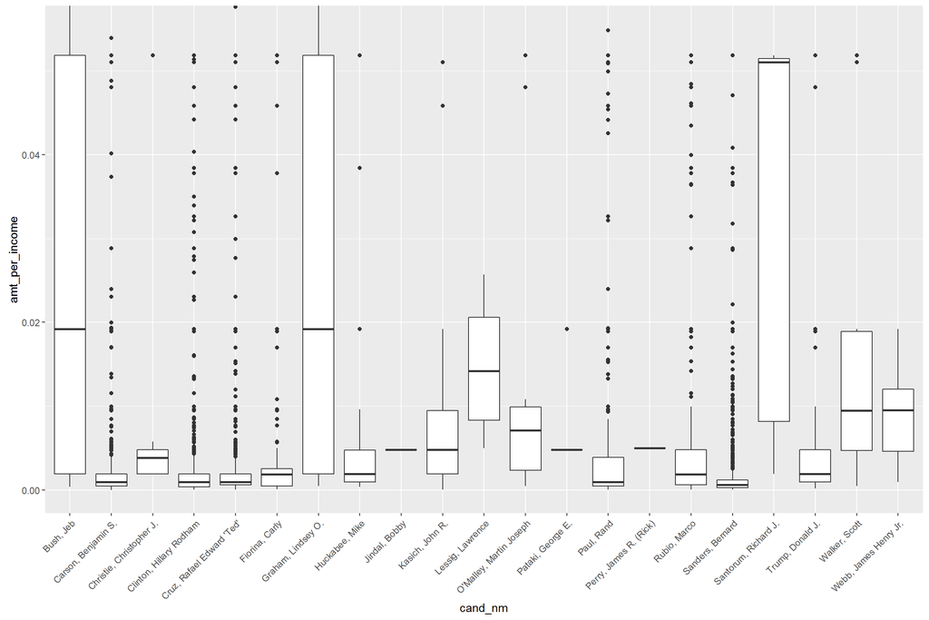

Most candidates third quartile is under 0.01, so let’s zoom in to that level.

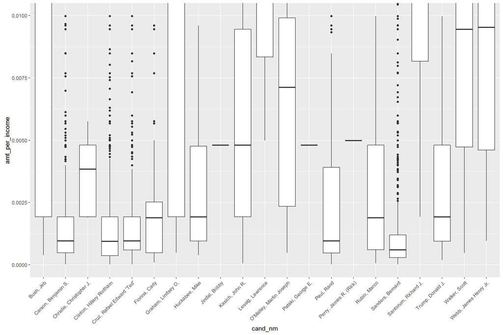

And let’s look by party.

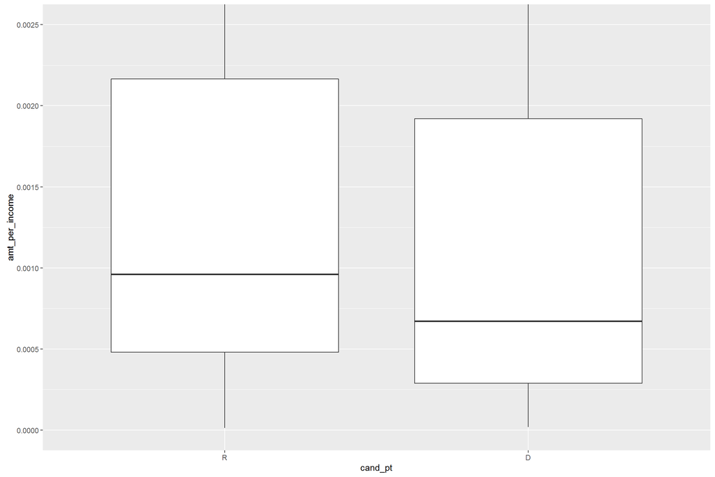

Next, let’s do a scatter plot of contribution amounts vs. median income.

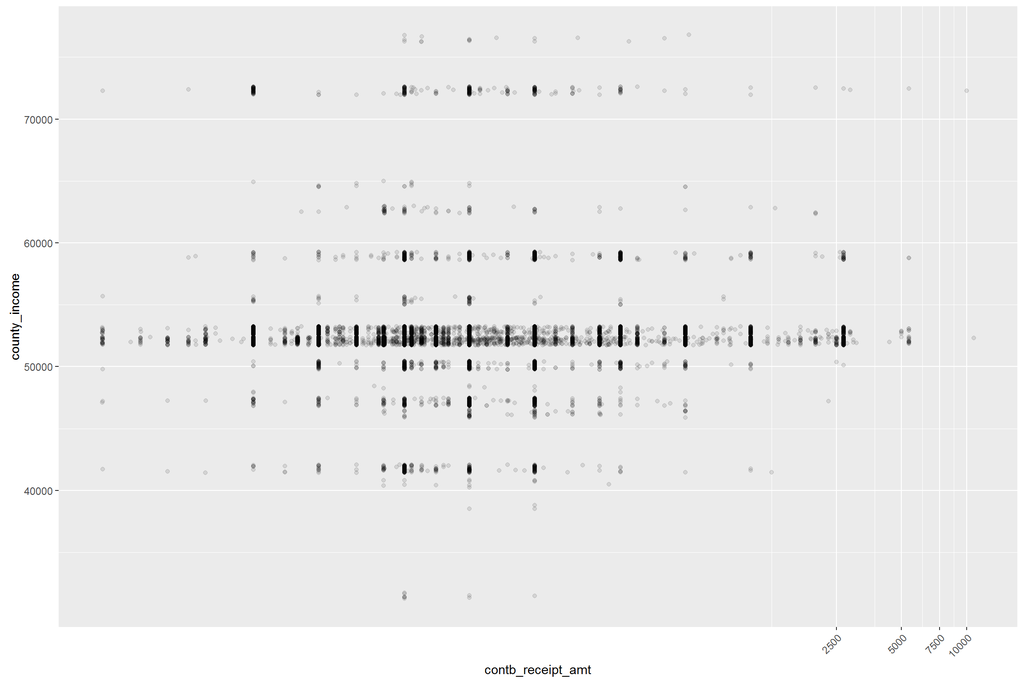

```
##
##  Pearson's product-moment correlation
##
## data:  pcf$contb_receipt_amt and pcf$county_income
## t = 2.527, df = 15023, p-value = 0.01151
## alternative hypothesis: true correlation is not equal to 0
## 95 percent confidence interval:
##  0.004624523 0.036590845
## sample estimates:
##        cor
## 0.02061295
```

There isn’t much correlation between income and contribution amount. The Pearson’s correlation coefficient between these two variables is only 0.02. Let’s see if counties with a larger population are more likely to have more contributions.

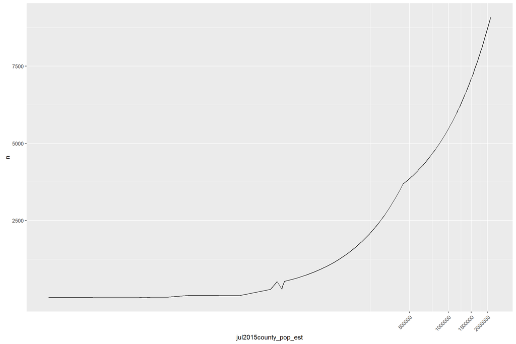

```
##
##  Pearson's product-moment correlation
##
## data:  pcf.by_county$n and pcf.by_county$jul2015county_pop_est
## t = 19.744, df = 14, p-value = 1.28e-11
## alternative hypothesis: true correlation is not equal to 0
## 95 percent confidence interval:
##  0.9490120 0.9940698
## sample estimates:
##       cor
## 0.9825133
```

Not surprisingly, there is a high correlation between county population and the number of contributions made. The Pearson’s correlation coefficient for these variables is 0.98, which is almost is close to being perfectly correlated. Let’s also look at total amount of contributions vs population.

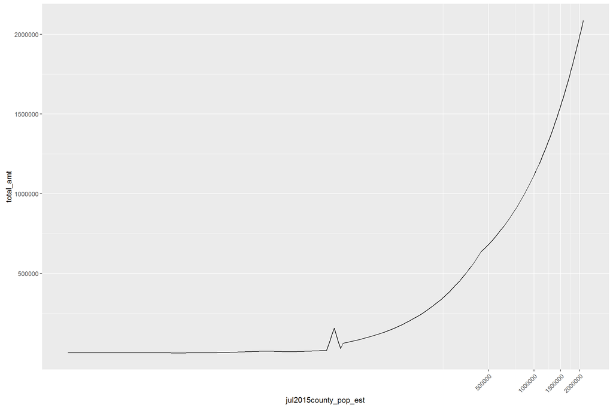

[output not shown]

It looks about the same. Let’s try breaking it out by party.

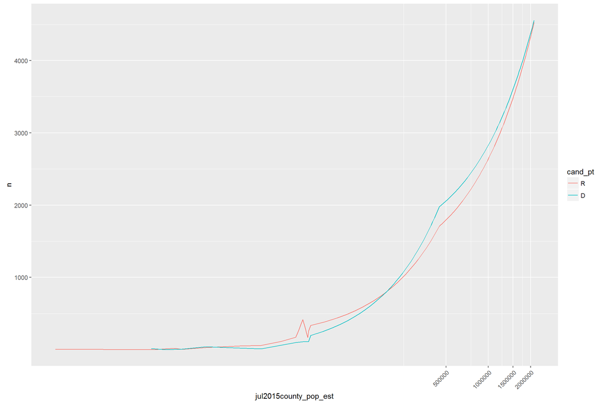

How about contributions over time per candidate?

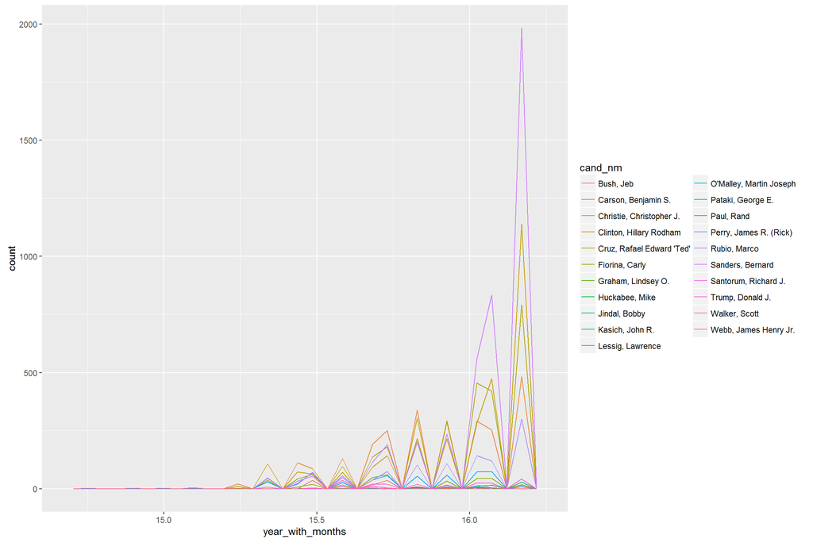

Hmm… that’s too many lines to be easy to read, let’s just try by party.

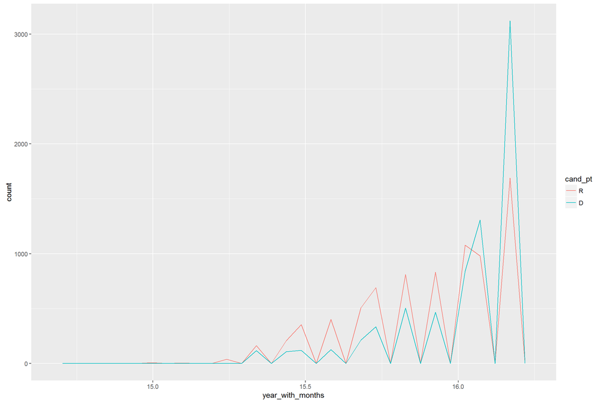

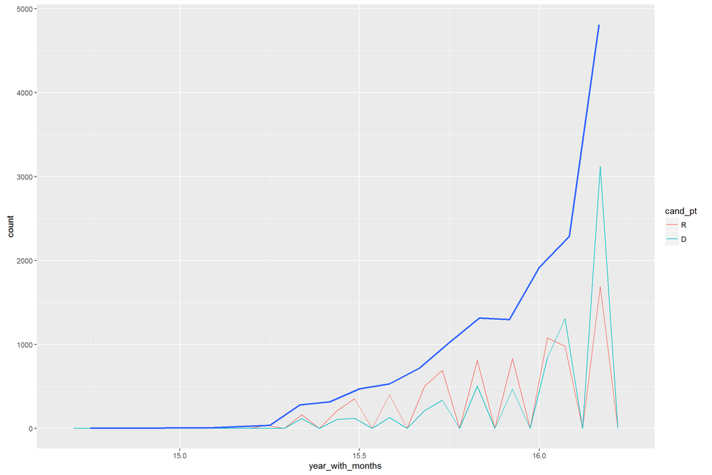

# Bivariate Analysis

### Talk about some of the relationships you observed in this part of the investigation. How did the feature(s) of interest vary with other features in the dataset?

The top 5 candidates in order of number of contributions are:

1. Bernie Sanders
2. Hillary Clinton
3. Ted Cruz
4. Ben Carson
5. Marco Rubio

The top 5 candidates in order of total amount of contributions are:

1. Hillary Clinton
2. Marco Rubio
3. Ted Cruz
4. Bernie Sanders
5. Ben Carson

Population was highly correlated with both number and total amount of contributions. Looking closer, it was interesting to see that there were more contributions to Democrats in places with higher populations, and more contributions to Republicans in places with lower populations.

Also, the number of contributions (for both parties) has steadily increased with time, but this is not surprising as the elections are coming up later this year.

### Did you observe any interesting relationships between the other features (not the main feature(s) of interest)?

It was interesting to see that there was very *low* correlation between contribution amount and median income. I would have thought that people who make more money would be making larger contributions, but for the most part, it seems that contribution amounts are independent of income and tend to gravitate toward nice round numbers like $25, $50, or $100, which I’m guessing are suggested donation amounts on donation forms or candidate websites.

### What was the strongest relationship you found?

The strongest relationship, with a correlation of .98, was between the number of contributions and the population of where those contributions came from. This is not surprising, but it at least shows that there aren’t unexpected relationships like certain low-population areas having a disproportionately high number of contributions.

# Multivariate Plots Section

Let’s try looking at what party people with certain occupations made contributions toward.

```
## Source: local data frame [30 x 5]
##
##                         contbr_occupation     n total_amt   mean_amt
##                                    (fctr) (int)     (dbl)      (dbl)
## 1                                 RETIRED  4374 639458.08  146.19526
## 2                            NOT EMPLOYED  1392 103238.34   74.16547
## 3  INFORMATION REQUESTED PER BEST EFFORTS   289 120697.32  417.63779
## 4                                ATTORNEY   212 123670.17  583.34986
## 5                               HOMEMAKER   212 138953.43  655.44071
## 6                               PHYSICIAN   202 106854.40  528.98218
## 7                              CONSULTANT   167  48024.25  287.57036
## 8                                   SALES   150  20541.65  136.94433
## 9                   INFORMATION REQUESTED   149  64421.77  432.36087
## 10                                TEACHER   142  15027.13  105.82486
## 11                                   NONE   134   9368.22   69.91209
```

[output cut: 20 more lines]

It looks like there are some occupations that need to be grouped together. For example, “NOT EMPLOYED” and “NONE” should be grouped, “LAWYER” and “ATTORNEY” should be grouped, etc. There are also a lot of unknowns as seen with the “INFORMATION REQUESTED PER BEST EFFORTS” category. So let’s do some cleanup.

```
## Source: local data frame [30 x 5]
##
##      contbr_occupation     n total_amt   mean_amt median_amt
##                 (fctr) (int)     (dbl)      (dbl)      (dbl)
## 1              RETIRED  4374 639458.08 146.195263      50.00
## 2           UNEMPLOYED  1556 113376.56  72.864113      27.00
## 3                  CEO   433 278804.95 643.891339     100.00
## 4               LAWYER   294 136660.68 464.832245     100.00
## 5              MANAGER   286  66862.35 233.784441      27.00
## 6                NURSE   238  21190.44  89.035462      30.00
## 7               DOCTOR   221 110789.40 501.309502     207.66
## 8        SELF EMPLOYED   214  35097.78 164.008318      50.00
## 9            HOMEMAKER   212 138953.43 655.440708      71.07
## 10               SALES   202  20851.65 103.225990      25.00
## 11          CONSULTANT   167  48024.25 287.570359     100.00
```

[output cut: 19 more lines]

There is still more clean up that could be done, but we cleaned up the top 30. Now, to make things more palatable, we will only look at occupations that have made 75 or more contributions.

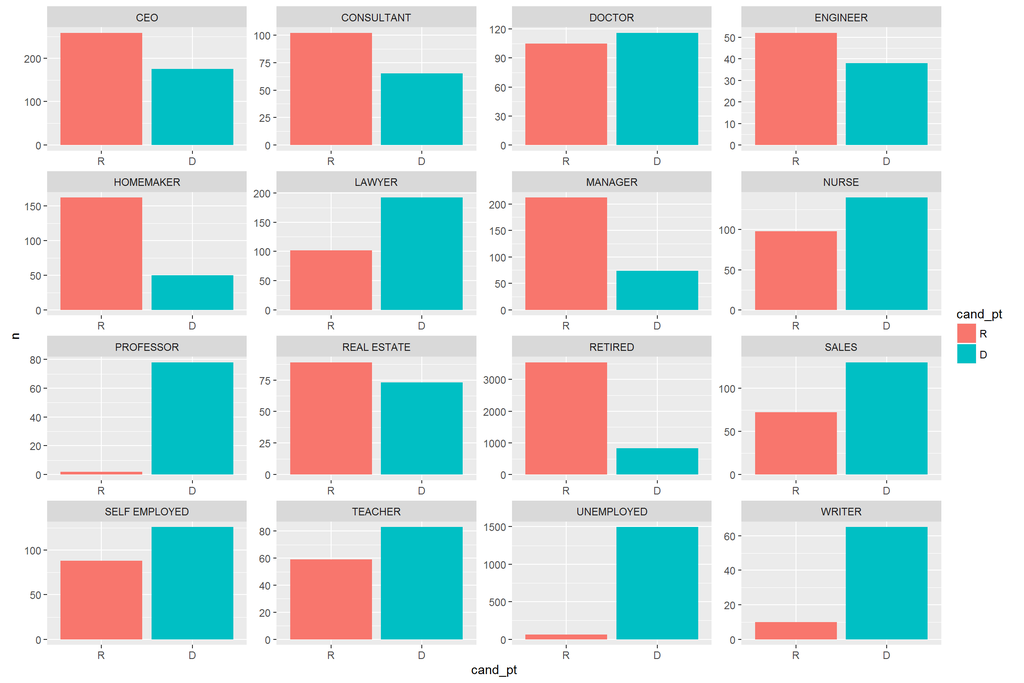

It looks like some occupations, such as professors and writers, are much more likely to contribute to Democrats, while other occupations, such as homemakers and retirees, are much more likely to contribute to Republicans. Others, such as doctors and people in real estate, seem to have a pretty even split.

Finally, I wanted to look at some statistics geographically on a map of Nevada. To do this, I borrowed some code from [Eduardo Leoni](http://stackoverflow.com/questions/1260965/developing-geographic-thematic-maps-with-r) and modified it for this data set.

First we’ll just look at a basic heat map of income by county.

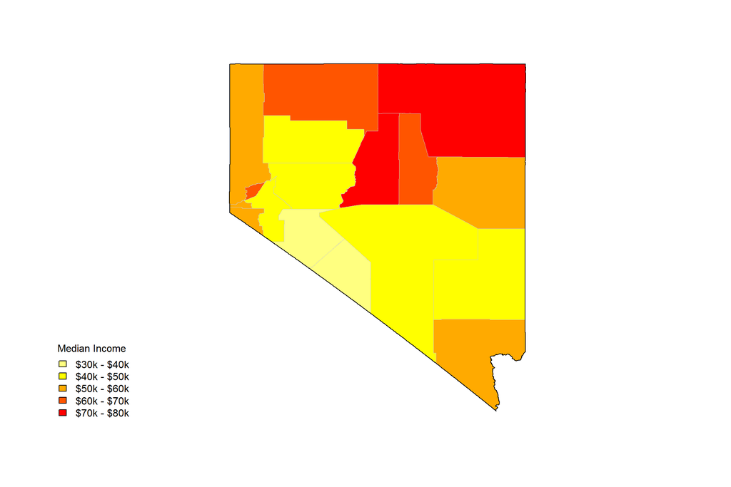

```
##         county county_income
## 1    Churchill         46195
## 2        Clark         52070
## 3      Douglas         58940
## 4         Elko         72280
## 5    Esmeralda         31528
## 6       Eureka         68403
## 7     Humboldt         62632
## 8       Lander         76558
## 9      Lincoln         40550
## 10        Lyon         47143
## 11     Mineral         38664
## 12         Nye         41757
## 13    Pershing         48165
## 14      Storey         64835
## 15      Washoe         52910
## 16  White Pine         55337
## 17 Carson City         50108
```

```
##    Min. 1st Qu.  Median    Mean 3rd Qu.    Max.
##   31530   46200   52070   53420   62630   76560
```

Median income by county ranges from $31,530 in Esmeralda County to $76,560 in Lander County. The mean of the median incomes is $53,420. It is kind of surprising that Clark County (where Las Vegas is) is not at the top of the list!

And let’s do the same for population.

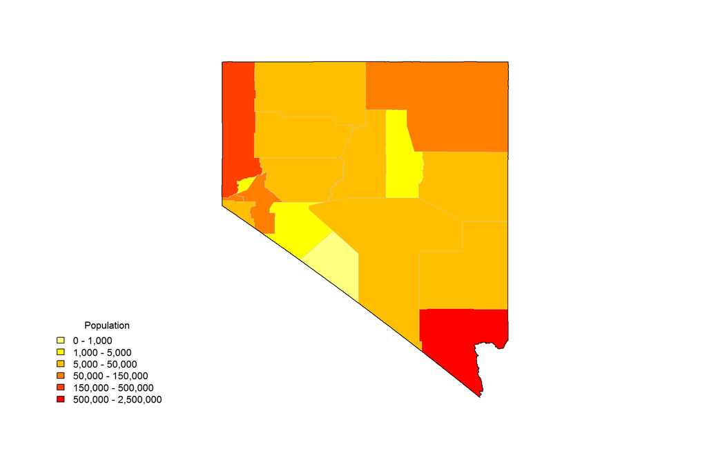

```
##         county jul2015county_pop_est
## 1    Churchill                 24200
## 2        Clark               2114801
## 3      Douglas                 47710
## 4         Elko                 51935
## 5    Esmeralda                   829
## 6       Eureka                  2016
## 7     Humboldt                 17019
## 8       Lander                  5903
## 9      Lincoln                  5036
## 10        Lyon                 52585
## 11     Mineral                  4478
## 12         Nye                 42477
## 13    Pershing                  6634
## 14      Storey                  3987
## 15      Washoe                446903
## 16  White Pine                  9811
## 17 Carson City                 54521
```

```
##    Min. 1st Qu.  Median    Mean 3rd Qu.    Max.
##     829    5036   17020  170000   51940 2115000
```

The least populated county is the same as the one with the lowest median income, Esmaralda County, with a population of only 829 people. The county with the largest population by a wide margin is Clark County (one again, where Las Vegas is) with a population of 2,115,000 people. The mean county population is 170,000 people and the median is 17,020 people.

Next, let’s make a few new variables that show the ratio of Democrat to Republican.

```r
pcf.by_county_amt_ratio <- spread(
  select(pcf.by_county_party, county, cand_pt, total_amt),
  cand_pt,
  total_amt,
  fill = 0)

pcf.by_county_amt_ratio$amt_percent_R <-
  pcf.by_county_amt_ratio$R / (pcf.by_county_amt_ratio$R + pcf.by_county_amt_ratio$D)
pcf.by_county_amt_ratio$amt_percent_D <-
  pcf.by_county_amt_ratio$D / (pcf.by_county_amt_ratio$R + pcf.by_county_amt_ratio$D)

pcf.by_county_n_ratio <- spread(
  select(pcf.by_county_party, county, cand_pt, n),
  cand_pt,
  n,
  fill = 0)

pcf.by_county_n_ratio$n_percent_R <-
  pcf.by_county_n_ratio$R / (pcf.by_county_n_ratio$R + pcf.by_county_n_ratio$D)
pcf.by_county_n_ratio$n_percent_D <-
  pcf.by_county_n_ratio$D / (pcf.by_county_n_ratio$R + pcf.by_county_n_ratio$D)
```

Finally, let’s plot the ratios on the map. First, we will plot the color of each county based on the percentage of the total contribution amount that is Republican or Democrat. 100% Democrat will be blue, 100% Republican will be red, and everything in between will be a mix of blue and red.

(Note that there were no contributions from Eureka county, so it will be uncolored in the following plots.)

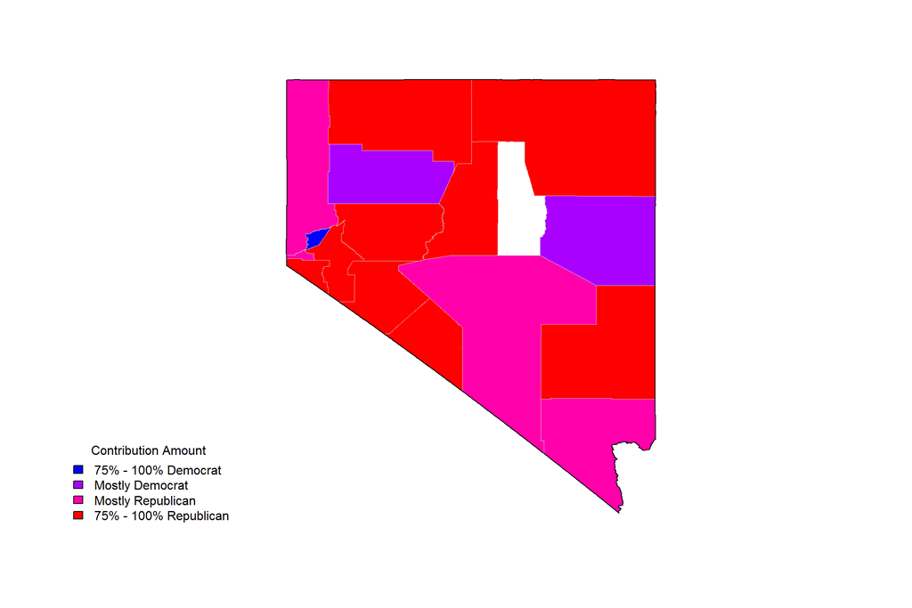

```
## Source: local data frame [16 x 5]
##
##         county          R         D amt_percent_R amt_percent_D
##         (fctr)      (dbl)     (dbl)         (dbl)         (dbl)
## 1  Carson City   45705.61  15691.65    0.74442426     0.2555757
## 2    Churchill    6653.27   1533.80    0.81265581     0.1873442
## 3        Clark 1145875.03 940993.54    0.54908826     0.4509117
## 4      Douglas  134291.07  21337.59    0.86289421     0.1371058
## 5         Elko   37556.50   4868.59    0.88524267     0.1147573
## 6    Esmeralda     350.00      0.00    1.00000000     0.0000000
## 7     Humboldt    9320.67   2666.48    0.77755513     0.2224449
## 8       Lander    1982.68      0.00    1.00000000     0.0000000
## 9      Lincoln     721.00    125.00    0.85224586     0.1477541
## 10        Lyon   21686.64   6600.96    0.76664828     0.2333517
## 11     Mineral     250.00      0.00    1.00000000     0.0000000
## 12         Nye   11634.52   5155.32    0.69295002     0.3070500
## 13    Pershing     328.75    578.14    0.36250262     0.6374974
## 14      Storey      35.00   1318.00    0.02586844     0.9741316
## 15      Washoe  454479.89 181073.79    0.71509285     0.2849072
## 16  White Pine    2328.00   2684.59    0.46443056     0.5355694
```

Next, let’s do the same for the total number of contributions.

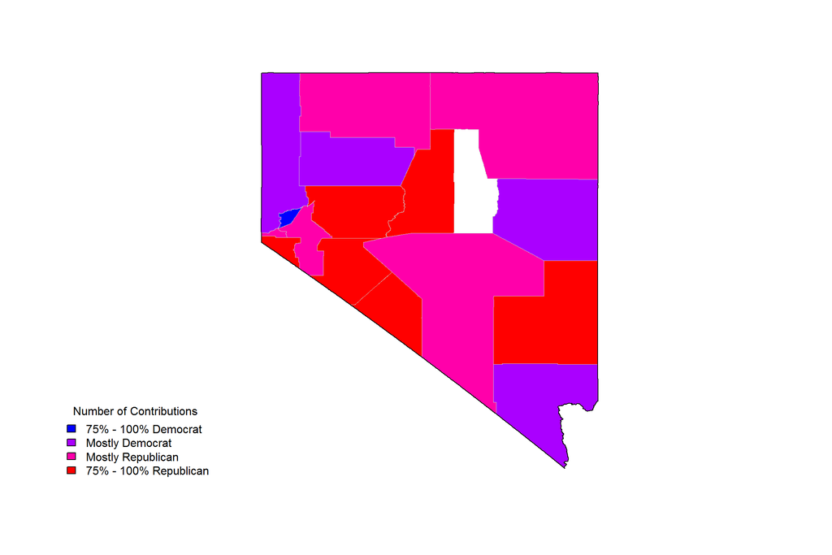

```
## Source: local data frame [16 x 5]
##
##         county     R     D n_percent_R n_percent_D
##         (fctr) (dbl) (dbl)       (dbl)       (dbl)
## 1  Carson City   334   196   0.6301887   0.3698113
## 2    Churchill    57    11   0.8382353   0.1617647
## 3        Clark  4528  4558   0.4983491   0.5016509
## 4      Douglas   414   109   0.7915870   0.2084130
## 5         Elko   168   110   0.6043165   0.3956835
## 6    Esmeralda     9     0   1.0000000   0.0000000
## 7     Humboldt    52    23   0.6933333   0.3066667
## 8       Lander    17     0   1.0000000   0.0000000
## 9      Lincoln    11     2   0.8461538   0.1538462
## 10        Lyon   260   112   0.6989247   0.3010753
## 11     Mineral     3     0   1.0000000   0.0000000
## 12         Nye   170    97   0.6367041   0.3632959
## 13    Pershing     3     8   0.2727273   0.7272727
## 14      Storey     2    16   0.1111111   0.8888889
## 15      Washoe  1707  1976   0.4634809   0.5365191
## 16  White Pine    31    41   0.4305556   0.5694444
```

Perhaps unsurprisingly, the counties with the highest *number* of contributions to Democrats and Republicans are also the counties with the highest *amount* of contributions.

As we saw in the univariate analysis section, Republicans have a big lead in total amount of contributions, but when it comes to total *number* of contributions, the map gets a lot more blue.

# Multivariate Analysis

### Talk about some of the relationships you observed in this part of the investigation. Were there features that strengthened each other in terms of looking at your feature(s) of interest?

It was interesting to see what proportions of different occupations made contributions to which party. Some occupations overwhelmingly contributed to one party, while others overwhelmingly contributed to the other–and some seemed to have an even split.

It was also interesting to see the differences between contribution amount and number of contributions on the map–especially when comparing those mappings to the population heat map. Places with higher populations tended to have more blue (contributions to Democrats), and places with lower populations tended to have more red (contributions to Republicans).

### Were there any interesting or surprising interactions between features?

I think the most interesting thing that popped out was the difference between total amount of contributions and total number of contributions. You would think that it would be independent of political party, but it looks like people who contribute to Republican candidates are more likely to give a bigger contribution than those who contribute to Democratic candidates. I’m sure that many political scientists and economists would have a lot to say about why this is, but I am not going to try to guess at these reasons and will leave such conclusions to the reader.

# Final Plots and Summary

### Plot One

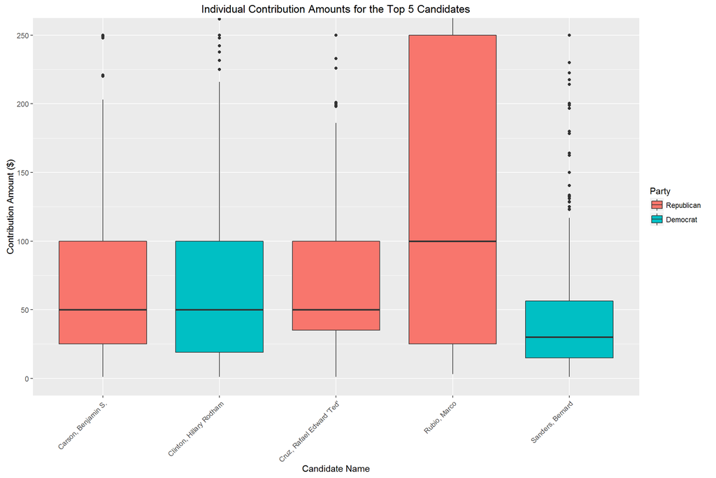

### Description One

These box plots show the quartiles of how much individual contributions amounted to for the top 5 candidates in the data. As you can see, Marco Rubio tends to get much more per contribution than the other candidates here and Bernie Sanders tends to get less per contribution. Interestingly, of these 5, Marco Rubio has the *fewest* contributions, and Bernie Sanders has the *most*.

For comparison, the overall median contribution amount was $50, the mean was $203.50, and the max was $10,800.